# Reproductive Health Behaviors in Developing Countries

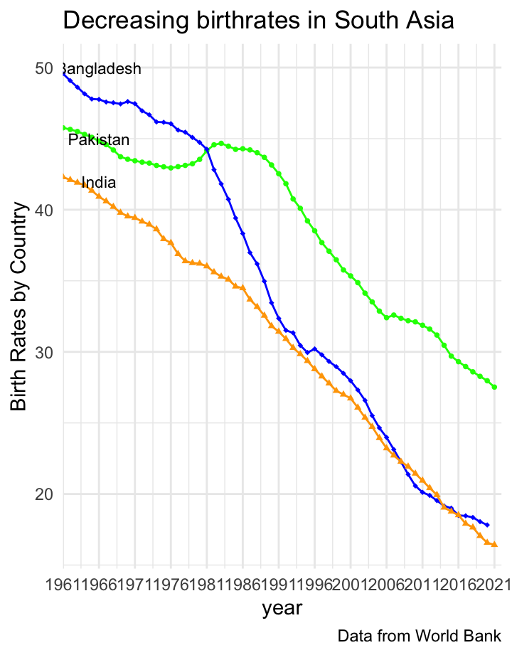

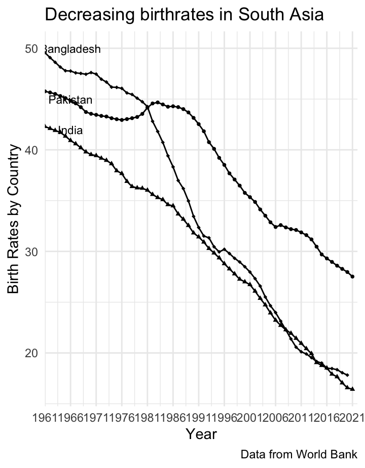

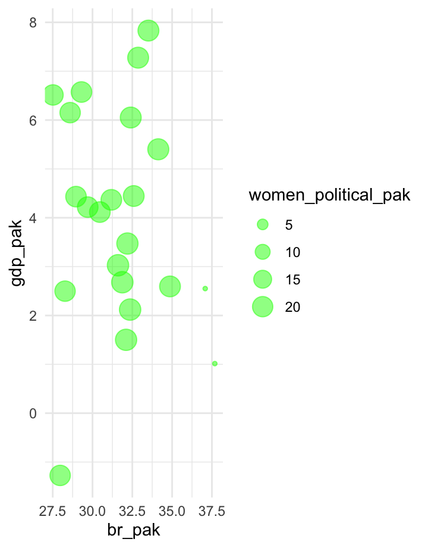

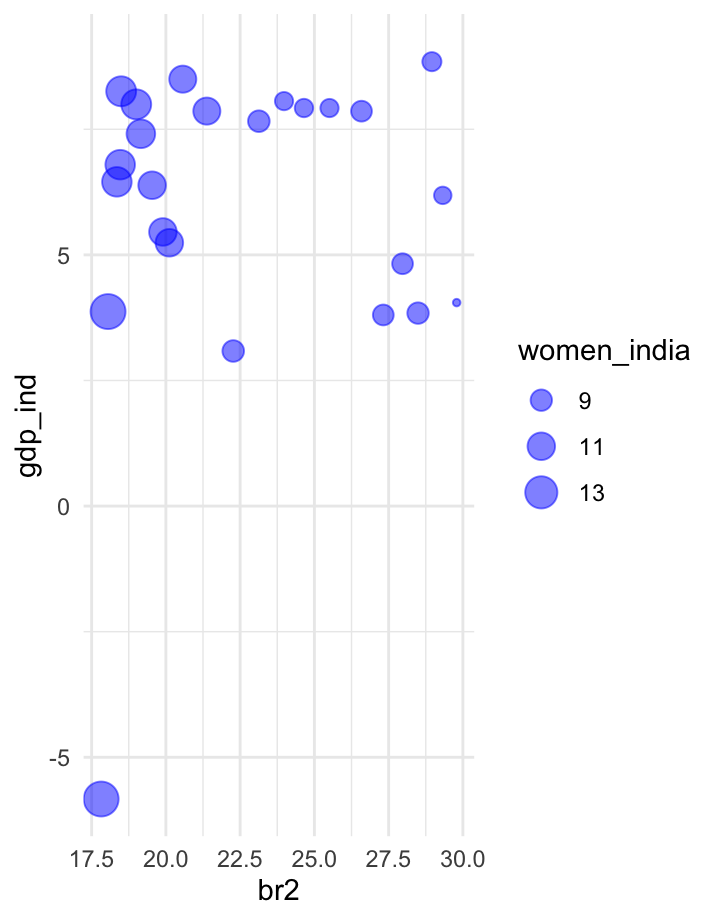

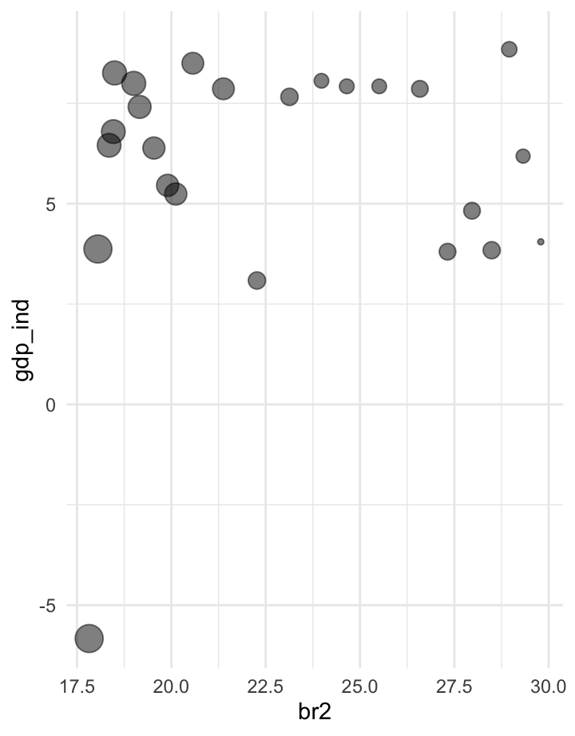

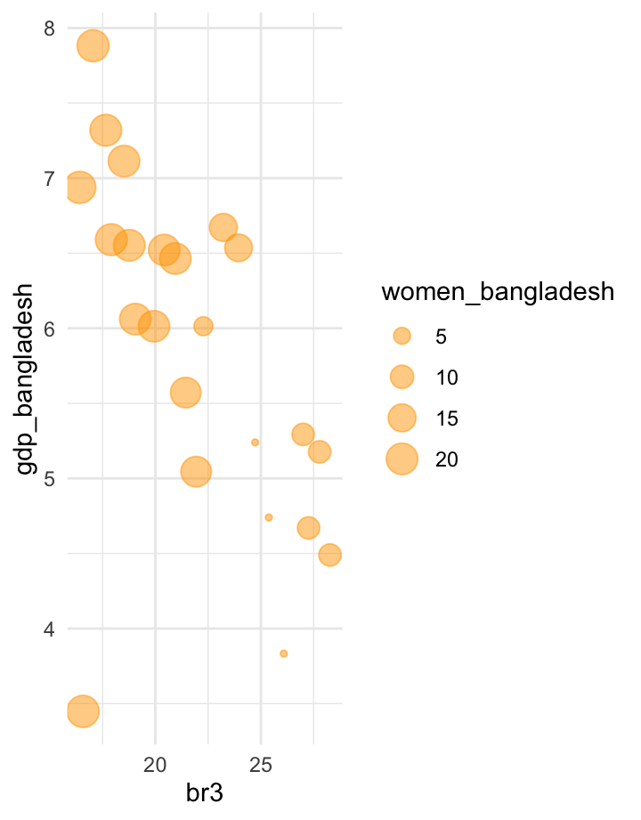

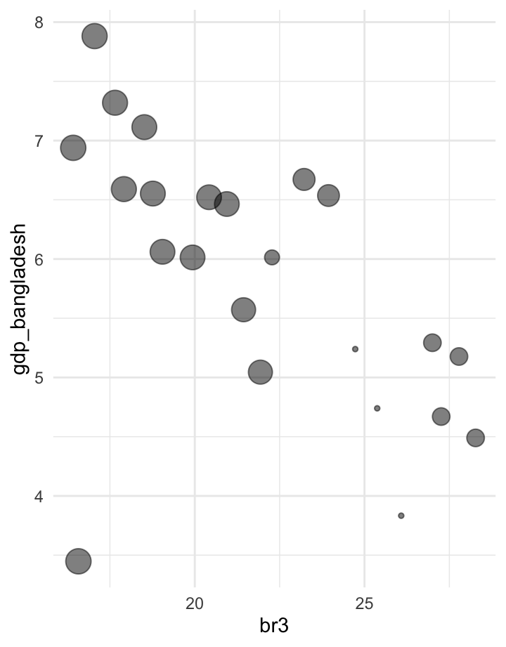

[figure not shown]

[figure not shown]

[figure not shown]

[figure not shown]

# Page 1

### Line Chart

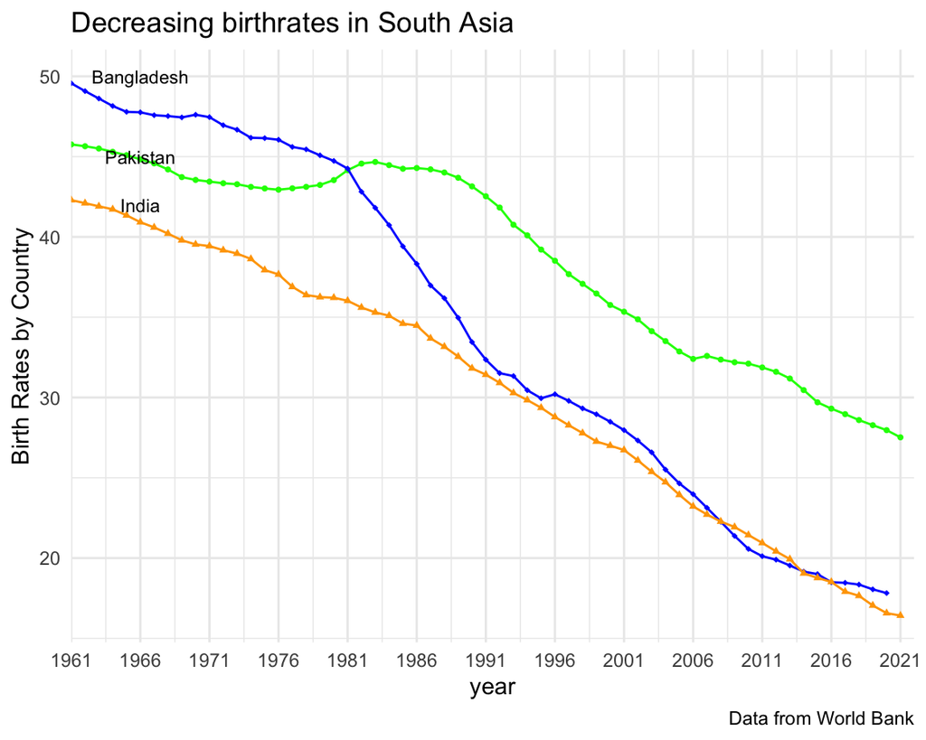

### Original

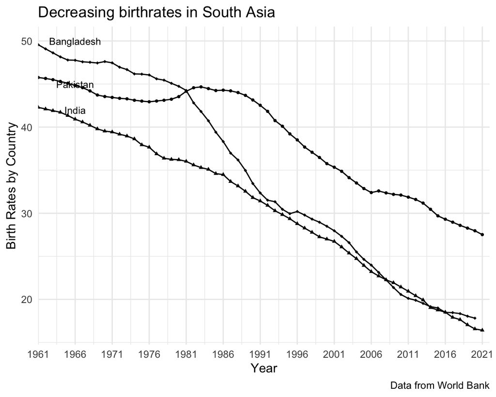

# Page 2

### Scatter Plot - Pakistan

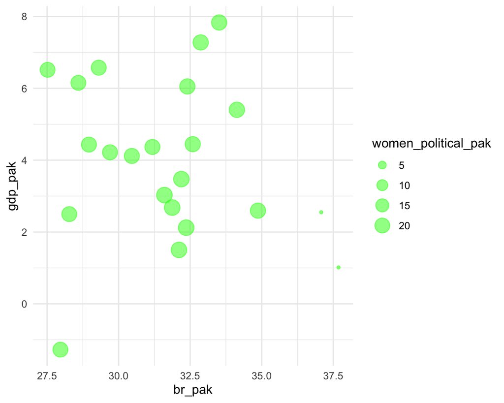

### Scatter Plot - India

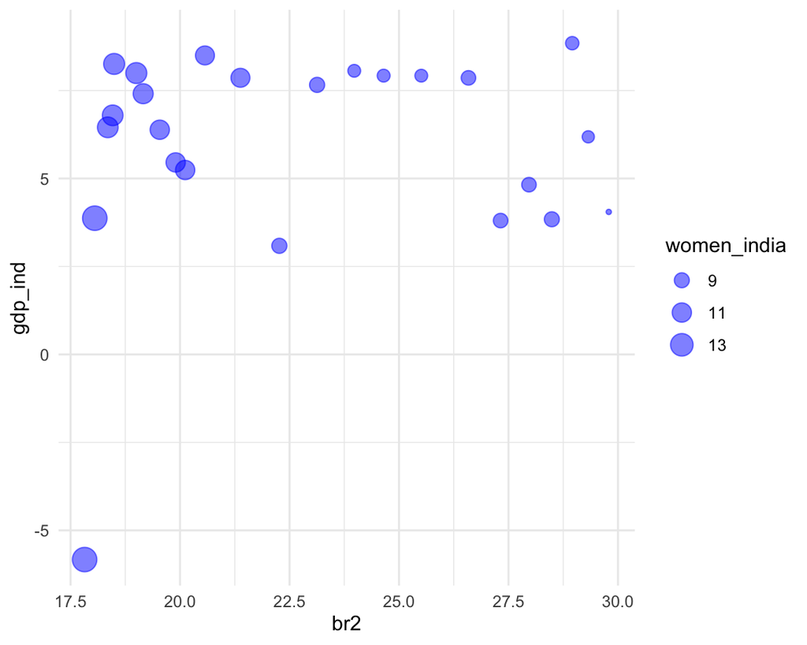

### About

The three scatterplots show how the indicators of women empowerment in each country including Pakistan, India, and Bangladesh impact birth rate. The variable “women’s_political_participation is used as the indicator of women empowerment.

### Original

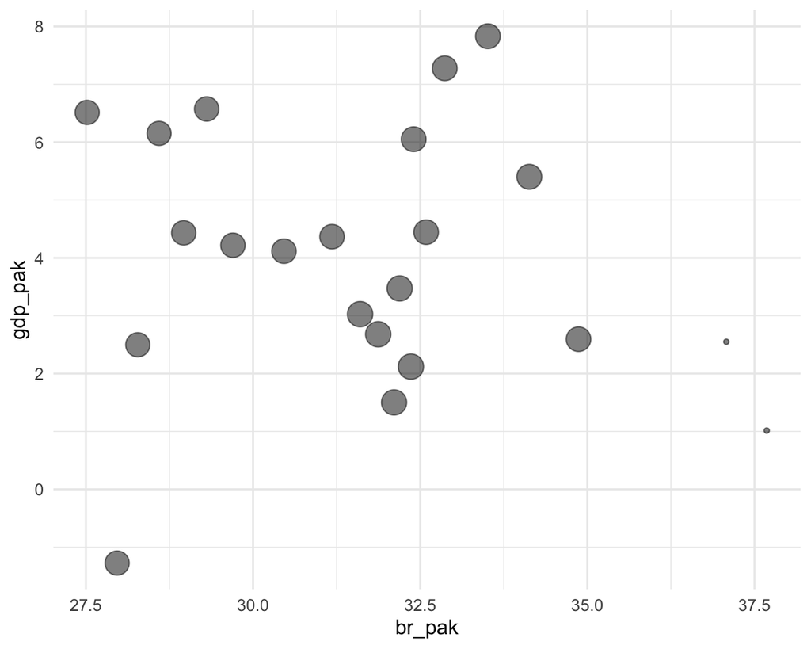

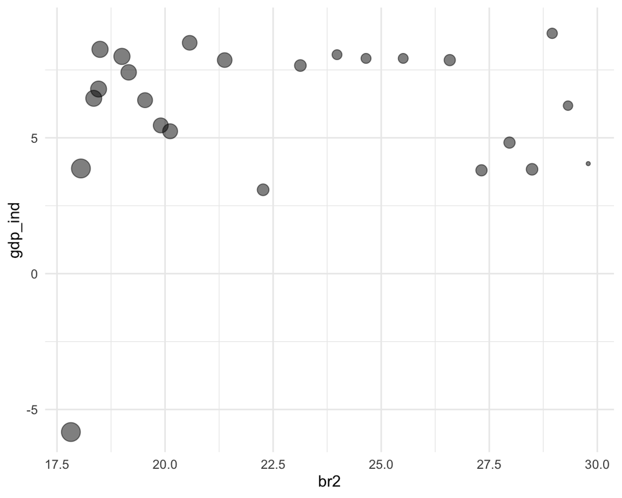

# Page 3

### Scatter Plot - Bangladesh

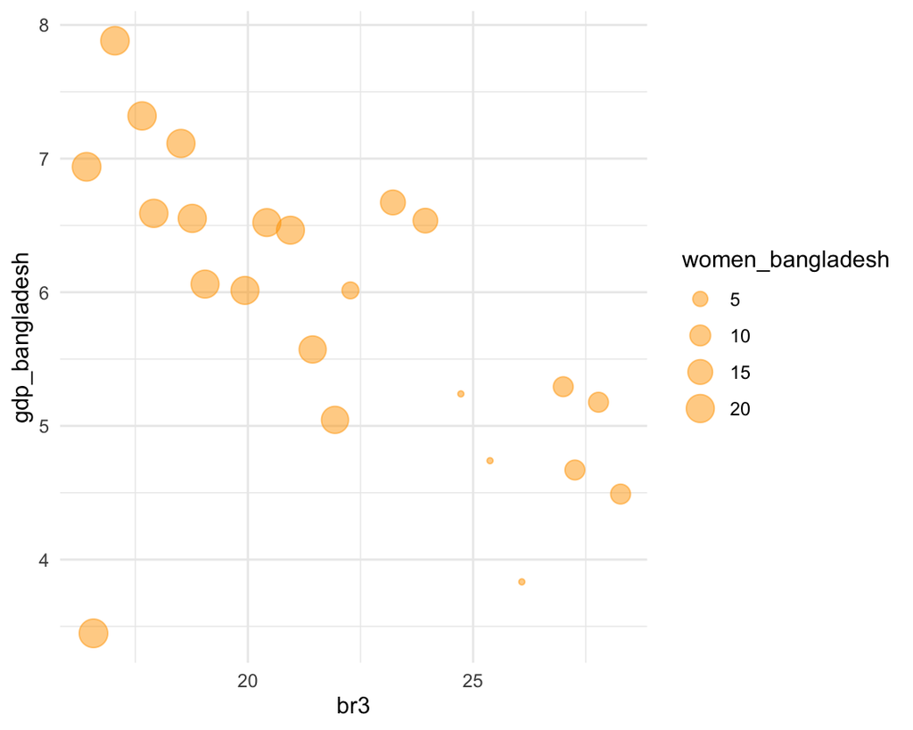

### About

In conclusion, this study aims to bridge the gap in literature by employing an extensive analysis of World Bank demographic data to explore the interconnections between GDP, birth rates, and women’s political participation in Pakistan, India, and Bangladesh. Through exploratory data analysis and innovative visualizations, the research intends to provide policymakers, public health officials, NGOs, and the academic community with actionable insights to refine and enhance family planning initiatives, considering the unique demographic and cultural contexts of South Asia.

### Original

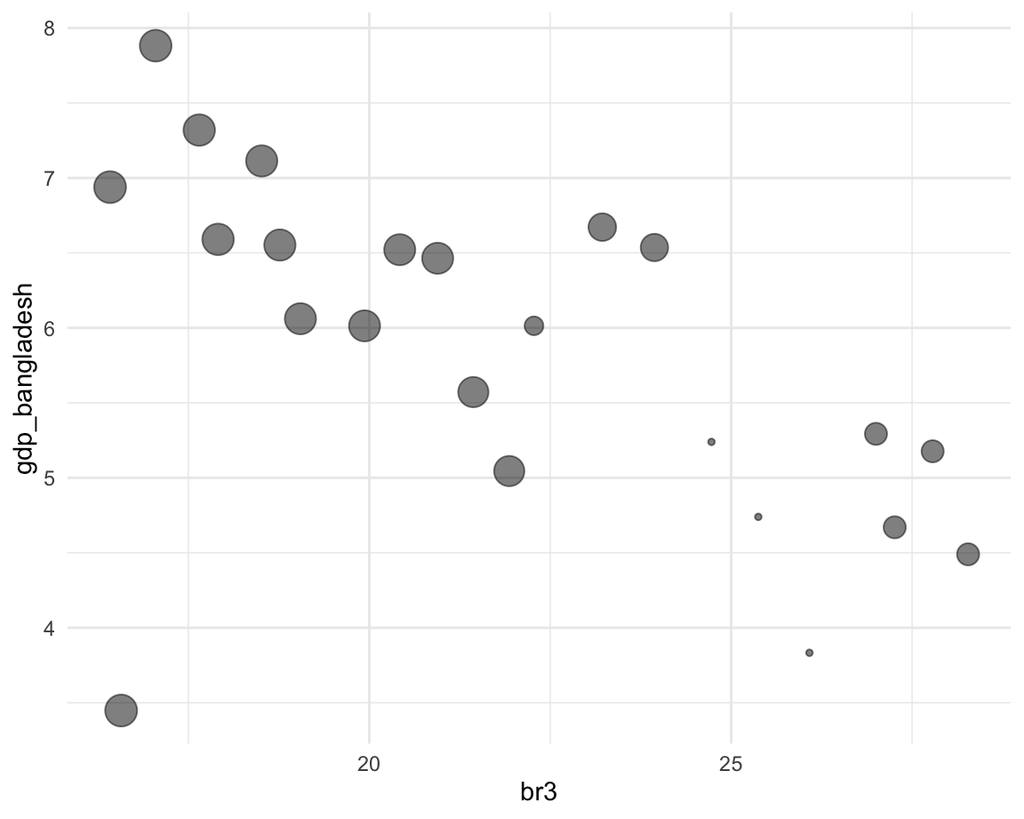

# Page 4

### Box Plot - Three South Asian Countries

[figure not shown]

### About

The Box Plot provides a statistical summary of the birth rates for Pakistan, India, and Bangladesh over the observed period. Each box represents one country and illustrates the central tendency and distribution spread of its birth rates. The bottom and top of each box indicate the first (Q1) and third (Q3) quartiles, with the band inside the box showing the median. The ends of the whiskers represent the lowest and highest values within 1.5 times the interquartile range (Q3 - Q1) from the quartiles, helping identify the range of most data points. Points outside the whiskers are considered outliers, which are individually plotted.

### Original

[figure not shown]

# Page 5

### Map Depicting Birth Rates in the 3 Countries

[figure not shown]

### About

[figure not shown]